# Recall performance for objects inside the rooms

# 1 Visual inspection of the data

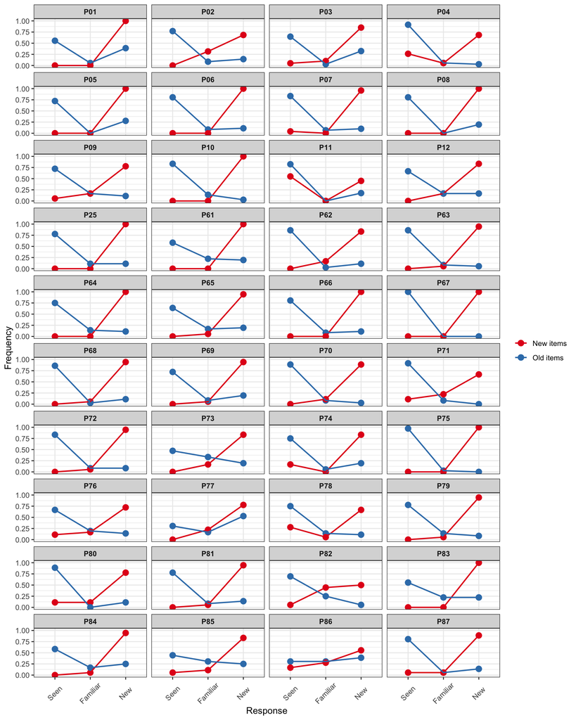

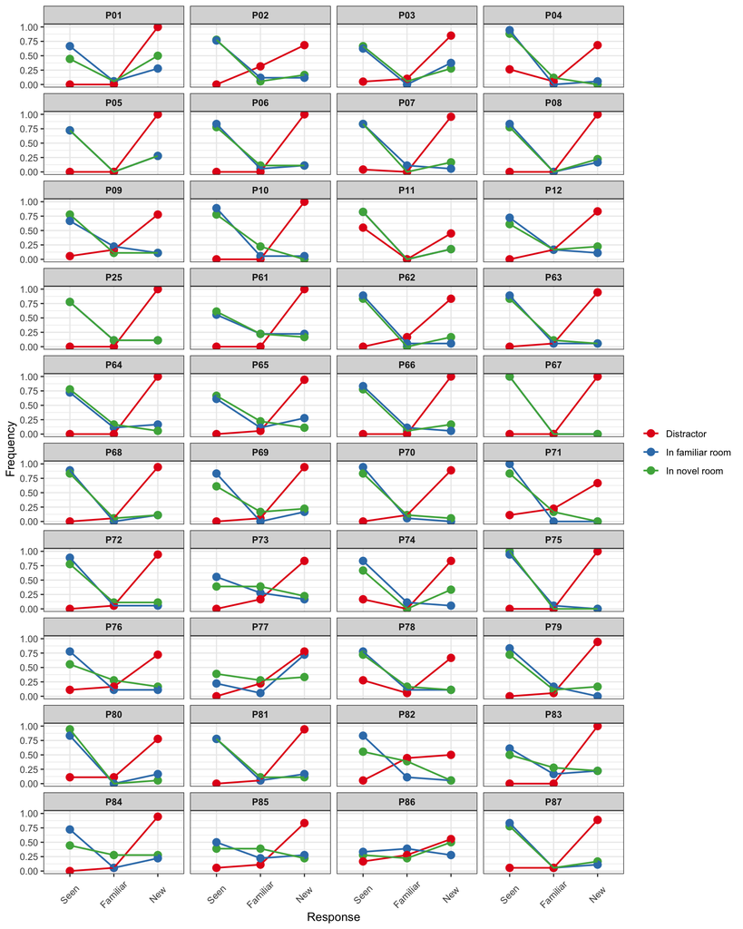

# 2 Novelty Benefits

## 2.1 Check the data

- **Is there any corrected hit rate < 0?**
  - There are 0 negative values.

## 2.2 Compare mean accuracy between *novel* and *familiar* rooms

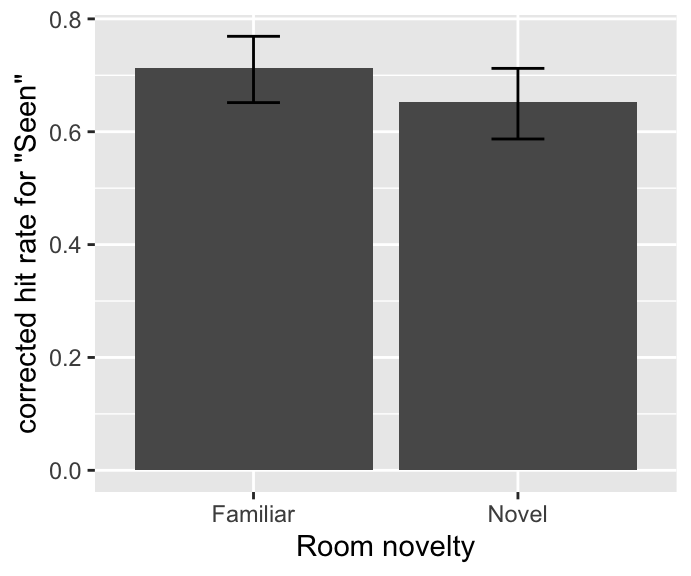

Figure1. Mean accuracy for item memory respectively for Familiar and Novel rooms.

```
##       Group      Mean        SD  N
## 1:    Novel 0.6531147 0.1981777 40
## 2: Familiar 0.7129554 0.1891087 40
```

```
##
##  Paired t-test
##
## data:  SAcc by Group
## t = 3.6203, df = 39, p-value = 0.0008362
## alternative hypothesis: true difference in means is not equal to 0
## 95 percent confidence interval:
##  0.02640735 0.09327402
## sample estimates:
## mean of the differences
##              0.05984069
```

## 2.3 Any difference between *Early* and *Later* object groups?

### 2.3.1 Check the data

- **Is there any corrected hit rate < 0?**
  - There are 0 negative values out of a total of 160 values.

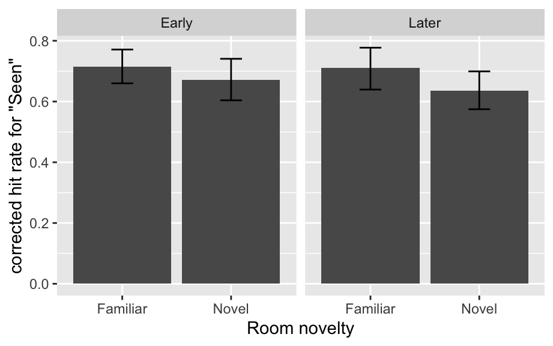

```
##       Group ObjOrdGrp      Mean        SD  N
## 1:    Novel     Early 0.6704349 0.2263053 40
## 2:    Novel     Later 0.6357127 0.2216787 40
## 3: Familiar     Later 0.7112088 0.2325430 40
## 4: Familiar     Early 0.7148794 0.1870703 40
```

```
## $ANOVA
##            Effect DFn DFd          F            p p<.05         ges
## 2           Group   1  39 13.2083924 0.0008030248     * 0.019100702
## 3       ObjOrdGrp   1  39  0.6294869 0.4323443538       0.001991263
## 4 Group:ObjOrdGrp   1  39  0.6165539 0.4370750714       0.001303450
```

# 3 Curiosity Enhancement

## 3.1 Check the data

### 3.1.1 Is there any corrected hit rate < 0?

#### 3.1.1.1 For the data per room

- There are 1 negative values out of a total of 239 values.

```
##    SubjectNo     Context    Group CurRating RoomOrder Duration SFHit SHit
## 1:       P86 StorageRoom Familiar         3    Second 86.98412   0.5    0
##       SrcHit   SFFalse    SFalse  SrcFalse      SFAcc       SAcc
## 1: 0.1666667 0.4444444 0.1666667 0.1111111 0.05555556 -0.1666667
##        SrcAcc
## 1: 0.05555556
```

#### 3.1.1.2 For the data per curiosity group

- There are 0 negative value for curiosity group (1 ~ 3 and 5 ~ 7) out of a total of 78 values.

#### 3.1.1.3 For the data per curiosity group (median)

- There are 0 negative value for curiosity group (median) out of a total of 79 values.

## 3.2 Mean accuracy of item memory as a function of curiosity rating

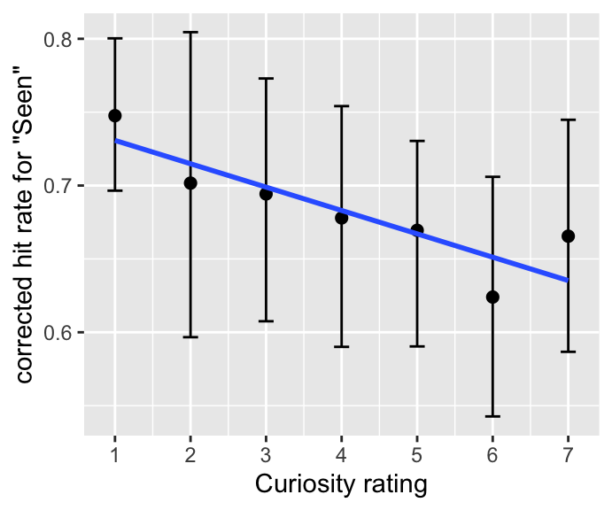

## 3.3 Testing the relationship between mean accuracy of item memory and curiosity rating

Build models with item memory accuracy as $y$ and examine effects of curiosity rating by including it into the model and then comparing the model fits.

- `baseline.rating` is the model with only an intercept, showing no change in item memory as a function of curiosity rating.
- `rating.intercept` is the model with $\small EncodingRating$ included, showing the effects of curiosity rating.
- `rating.slope` is the model allowing the slope (i.e., relationship between item memory and curiosity rating) varying across participants.

```
##                  Model df       AIC       BIC   logLik   Test  L.Ratio
## baseline.rating      1  3  -97.9966 -87.56721 51.99830
## rating.intercept     2  4 -104.4375 -90.53164 56.21875 1 vs 2 8.440891
## rating.slope         3  6 -100.4347 -79.57597 56.21737 2 vs 3 0.002745
##                  p-value
## baseline.rating
## rating.intercept  0.0037
## rating.slope      0.9986
```

```
## Linear mixed-effects model fit by maximum likelihood
##  Data: inside.hit.rate.per.room
##         AIC       BIC   logLik
##   -100.4347 -79.57597 56.21737
##
## Random effects:
##  Formula: ~1 + CurRating | SubjectNo
##  Structure: General positive-definite, Log-Cholesky parametrization
##             StdDev       Corr
## (Intercept) 0.1719124747 (Intr)
## CurRating   0.0004490716 0.009
## Residual    0.1610291325
##
## Fixed effects: SAcc ~ CurRating
##                  Value  Std.Error  DF   t-value p-value
## (Intercept)  0.7462330 0.03644950 198 20.473066  0.0000
## CurRating   -0.0156924 0.00536857 198 -2.923016  0.0039
##  Correlation:
##           (Intr)
## CurRating -0.597
##
## Standardized Within-Group Residuals:
##        Min         Q1        Med         Q3        Max
## -2.6934437 -0.5715103  0.1216135  0.6051534  2.4231722
##
## Number of Observations: 239
## Number of Groups: 40
```

## 3.4 Check the curiosity groups

### 3.4.1 Separate the groups according to the rating

- *High*: curiosity rating > 4
- *Low*: curiosity rating < 4
- For curiosity rating = 4, discarded

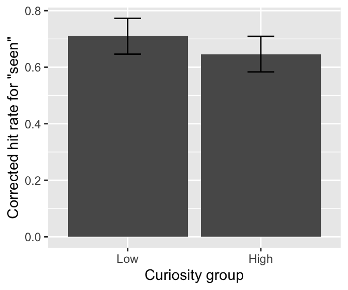

```
## Linear mixed-effects model fit by maximum likelihood
##  Data: inside.hit.rate.curiosity.group
##        AIC       BIC   logLik
##   -65.4875 -51.34725 38.74375
##
## Random effects:
##  Formula: ~1 + CurGrp | SubjectNo
##  Structure: General positive-definite, Log-Cholesky parametrization
##             StdDev     Corr
## (Intercept) 0.20451855 (Intr)
## CurGrpHigh  0.07110905 -0.27
## Residual    0.05542611
##
## Fixed effects: SAcc ~ CurGrp
##                  Value  Std.Error DF   t-value p-value
## (Intercept)  0.7033775 0.03415546 39 20.593411  0.0000
## CurGrpHigh  -0.0584634 0.01737650 37 -3.364507  0.0018
##  Correlation:
##            (Intr)
## CurGrpHigh -0.327
##
## Standardized Within-Group Residuals:
##         Min          Q1         Med          Q3         Max
## -1.44334699 -0.32147525  0.05336239  0.37277305  1.31024601
##
## Number of Observations: 78
## Number of Groups: 40
```

### 3.4.2 Curiosity groups and temporal order of the objects

#### 3.4.2.1 Check the data

- **Is there any corrected hit rate < 0?**
  - There are 1 negative values out of a total of 190 values.

```
##    SubjectNo CurGrp ObjOrdGrp SFHit SHit    SrcHit SFFalse SFalse
## 1:       P11   High     Later   0.5  0.5 0.3333333    0.55   0.55
##     SrcFalse SFAcc  SAcc SrcAcc
## 1: 0.1833333 -0.05 -0.05   0.15
```

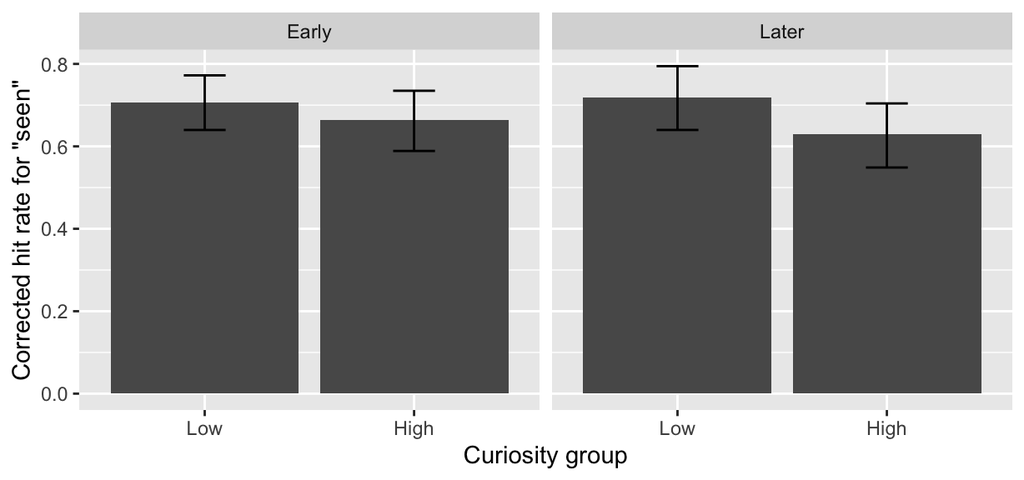

```
##    CurGrp ObjOrdGrp      Mean        SD  N
## 1:   High     Early 0.6637683 0.2353545 40
## 2:   High     Later 0.6297405 0.2456582 40
## 3:    Low     Later 0.7190982 0.2412999 38
## 4:   <NA>     Later 0.6684773 0.3025263 17
## 5:    Low     Early 0.7059403 0.2175777 38
## 6:   <NA>     Early 0.7221018 0.2541094 17
```

```
##           Model df       AIC       BIC   logLik   Test  L.Ratio p-value
## baseline      1  8 -68.33649 -43.93764 42.16824
## ord.model     2  9 -67.67107 -40.22237 42.83554 1 vs 2 1.334585  0.2480
## cur.model     3 10 -73.28915 -42.79059 46.64457 2 vs 3 7.618074  0.0058
## int.model     4 11 -72.74445 -39.19604 47.37223 3 vs 4 1.455307  0.2277
```

```
## Linear mixed-effects model fit by maximum likelihood
##  Data: inside.hit.rate.item.order.curiosity[!is.na(CurGrp)]
##         AIC       BIC   logLik
##   -72.74445 -39.19604 47.37223
##
## Random effects:
##  Formula: ~1 + CurGrp + ObjOrdGrp | SubjectNo
##  Structure: General positive-definite, Log-Cholesky parametrization
##                StdDev     Corr
## (Intercept)    0.18720274 (Intr) CrGrpH
## CurGrpHigh     0.04060049 -0.005
## ObjOrdGrpLater 0.13999807  0.009 -0.996
## Residual       0.11616669
##
## Fixed effects: SAcc ~ ObjOrdGrp + CurGrp + ObjOrdGrp:CurGrp
##                                Value  Std.Error  DF   t-value p-value
## (Intercept)                0.6983898 0.03566163 113 19.583786  0.0000
## ObjOrdGrpLater             0.0112767 0.03531215 113  0.319343  0.7501
## CurGrpHigh                -0.0346215 0.02758830 113 -1.254934  0.2121
## ObjOrdGrpLater:CurGrpHigh -0.0453045 0.03790195 113 -1.195307  0.2345
##  Correlation:
##                           (Intr) ObjOGL CrGrpH
## ObjOrdGrpLater            -0.287
## CurGrpHigh                -0.380  0.228
## ObjOrdGrpLater:CurGrpHigh  0.272 -0.556 -0.682
##
## Standardized Within-Group Residuals:
##         Min          Q1         Med          Q3         Max
## -2.88449554 -0.42480071  0.03866108  0.52611567  2.20406471
##
## Number of Observations: 156
## Number of Groups: 40
```

#### 3.4.2.2 *Post hoc*

```
##
##   Simultaneous Tests for General Linear Hypotheses
##
## Fit: lme.formula(fixed = SAcc ~ ObjOrdGrp + CurGrp + ObjOrdGrp:CurGrp,
##     data = inside.hit.rate.item.order.curiosity[!is.na(CurGrp)],
##     random = ~1 + CurGrp + ObjOrdGrp | SubjectNo, method = "ML",
##     na.action = na.exclude, control = list(msMaxIter = 500, opt = "optim",
##         msVerbose = FALSE))
##
## Linear Hypotheses:
##                          Estimate Std. Error z value Pr(>|z|)
## Early: High vs. Low == 0 -0.03462    0.02723  -1.271  0.20361
## Late:  High vs. Low == 0 -0.07993    0.02741  -2.916  0.00354 **
## ---
## Signif. codes:  0 '***' 0.001 '**' 0.01 '*' 0.05 '.' 0.1 ' ' 1
## (Adjusted p values reported -- none method)
```

### 3.4.3 Separate the groups according to the median rating of each participant

- *High*: curiosity rating > median of the participant
- *Low*: curiosity rating < median of the participant

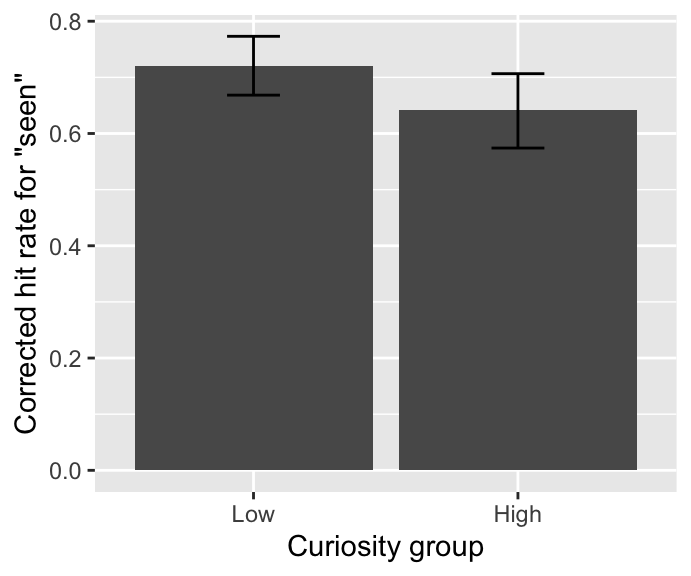

```
## Linear mixed-effects model fit by maximum likelihood
##  Data: inside.hit.rate.curiosity.group.median
##         AIC       BIC  logLik
##   -84.52661 -70.30992 48.2633
##
## Random effects:
##  Formula: ~1 + CurGrpMedian | SubjectNo
##  Structure: General positive-definite, Log-Cholesky parametrization
##                  StdDev     Corr
## (Intercept)      0.17003266 (Intr)
## CurGrpMedianHigh 0.06803204 0.273
## Residual         0.04878618
##
## Fixed effects: SAcc ~ CurGrpMedian
##                       Value  Std.Error DF   t-value p-value
## (Intercept)       0.7204349 0.02833018 39 25.429949       0
## CurGrpMedianHigh -0.0787009 0.01571534 38 -5.007903       0
##  Correlation:
##                  (Intr)
## CurGrpMedianHigh 0.045
##
## Standardized Within-Group Residuals:
##         Min          Q1         Med          Q3         Max
## -1.19772342 -0.33024646  0.06743736  0.39750150  1.15924707
##
## Number of Observations: 79
## Number of Groups: 40
```

#### 3.4.3.1 Curiosity groups and temporal order of the objects

##### 3.4.3.1.1 Check the data

```
##    SubjectNo CurGrpMedian ObjOrdGrp SFHit SHit    SrcHit SFFalse SFalse
## 1:       P11         High     Later   0.5  0.5 0.3333333    0.55   0.55
##     SrcFalse SFAcc  SAcc SrcAcc
## 1: 0.1833333 -0.05 -0.05   0.15
```

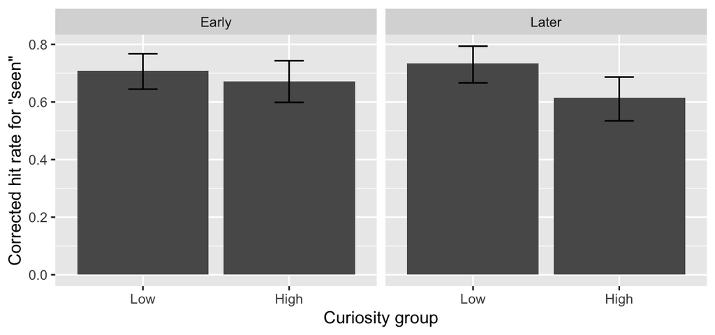

```
##    CurGrpMedian ObjOrdGrp      Mean        SD  N
## 1:         High     Early 0.6715999 0.2315399 39
## 2:         High     Later 0.6153321 0.2428238 39
## 3:          Low     Later 0.7335302 0.2176017 40
## 4:          Low     Early 0.7079349 0.1929949 40
```

```
##           Model df       AIC       BIC   logLik   Test   L.Ratio p-value
## baseline      1  8 -81.35704 -56.85628 48.67852
## ord.model     2  9 -79.82860 -52.26525 48.91430 1 vs 2  0.471560  0.4923
## cur.model     3 10 -91.13926 -60.51331 55.56963 2 vs 3 13.310657  0.0003
## int.model     4 11 -93.69226 -60.00371 57.84613 3 vs 4  4.552998  0.0329
```

```
## Linear mixed-effects model fit by maximum likelihood
##  Data: inside.hit.rate.item.order.curiosity.median
##         AIC       BIC   logLik
##   -93.69226 -60.00371 57.84613
##
## Random effects:
##  Formula: ~1 + CurGrpMedian + ObjOrdGrp | SubjectNo
##  Structure: General positive-definite, Log-Cholesky parametrization
##                  StdDev     Corr
## (Intercept)      0.15268742 (Intr) CrGrMH
## CurGrpMedianHigh 0.03757761  0.918
## ObjOrdGrpLater   0.09807918  0.023 -0.326
## Residual         0.11758276
##
## Fixed effects: SAcc ~ ObjOrdGrp + CurGrpMedian + ObjOrdGrp:CurGrpMedian
##                                      Value  Std.Error  DF   t-value
## (Intercept)                      0.7079349 0.03086414 115 22.937135
## ObjOrdGrpLater                   0.0255952 0.03091885 115  0.827820
## CurGrpMedianHigh                -0.0371353 0.02759416 115 -1.345765
## ObjOrdGrpLater:CurGrpMedianHigh -0.0810265 0.03796133 115 -2.134448
##                                 p-value
## (Intercept)                      0.0000
## ObjOrdGrpLater                   0.4095
## CurGrpMedianHigh                 0.1810
## ObjOrdGrpLater:CurGrpMedianHigh  0.0349
##  Correlation:
##                                 (Intr) ObjOGL CrGrMH
## ObjOrdGrpLater                  -0.362
## CurGrpMedianHigh                -0.258  0.379
## ObjOrdGrpLater:CurGrpMedianHigh  0.303 -0.604 -0.688
##
## Standardized Within-Group Residuals:
##        Min         Q1        Med         Q3        Max
## -2.0049568 -0.4783231  0.1080395  0.5842402  2.2842757
##
## Number of Observations: 158
## Number of Groups: 40
```

##### 3.4.3.1.2 *Post hoc*

```
##
##   Simultaneous Tests for General Linear Hypotheses
##
## Fit: lme.formula(fixed = SAcc ~ ObjOrdGrp + CurGrpMedian + ObjOrdGrp:CurGrpMedian,
##     data = inside.hit.rate.item.order.curiosity.median, random = ~1 +
##         CurGrpMedian + ObjOrdGrp | SubjectNo, method = "ML",
##     na.action = na.exclude, control = list(msMaxIter = 500, opt = "optim",
##         msVerbose = FALSE))
##
## Linear Hypotheses:
##                          Estimate Std. Error z value Pr(>|z|)
## Early: High vs. Low == 0 -0.03714    0.02724  -1.363    0.173
## Late:  High vs. Low == 0 -0.11816    0.02723  -4.340 1.43e-05 ***
## ---
## Signif. codes:  0 '***' 0.001 '**' 0.01 '*' 0.05 '.' 0.1 ' ' 1
## (Adjusted p values reported -- none method)
```

# 4 **Novelty** or **Curiosity**?

## 4.1 For Curiosity group splitted by score (*Low*: 1 ~ 3; *High*: 5 ~ 7)

### 4.1.1 Curiosity first, novelty next

```
##               Model df       AIC       BIC   logLik   Test  L.Ratio
## base.model        1  8 -82.39079 -55.38856 49.19539
## cur.scr.model     2  9 -87.27908 -56.90158 52.63954 1 vs 2 6.888296
## nov.scr.model     3 10 -85.29719 -51.54440 52.64859 2 vs 3 0.018100
##               p-value
## base.model
## cur.scr.model  0.0087
## nov.scr.model  0.8930
```

```
## Linear mixed-effects model fit by maximum likelihood
##  Data: inside.hit.rate.per.room[!is.na(CurGrp)]
##         AIC       BIC   logLik
##   -87.27908 -56.90158 52.63954
##
## Random effects:
##  Formula: ~1 + CurGrp + Group | SubjectNo
##  Structure: General positive-definite, Log-Cholesky parametrization
##             StdDev       Corr
## (Intercept) 0.1849859840 (Intr) CrGrpL
## CurGrpLow   0.0011981900 -0.003
## GroupNovel  0.0002573702  0.000  0.012
## Residual    0.1554991590
##
## Fixed effects: SAcc ~ CurGrp
##                 Value  Std.Error  DF   t-value p-value
## (Intercept) 0.6480063 0.03301113 175 19.629934  0.0000
## CurGrpLow   0.0603443 0.02201282 175  2.741325  0.0068
##  Correlation:
##           (Intr)
## CurGrpLow -0.316
##
## Standardized Within-Group Residuals:
##        Min         Q1        Med         Q3        Max
## -2.8799615 -0.5715136  0.1644333  0.6187733  1.9886552
##
## Number of Observations: 216
## Number of Groups: 40
```

### 4.1.2 Novelty first, curiosity next

```
##               Model df       AIC       BIC   logLik   Test  L.Ratio
## base.model        1  8 -82.39079 -55.38856 49.19539
## nov.scr.model     2  9 -86.53147 -56.15397 52.26574 1 vs 2 6.140686
## cur.scr.model     3 10 -85.29719 -51.54440 52.64859 2 vs 3 0.765710
##               p-value
## base.model
## nov.scr.model  0.0132
## cur.scr.model  0.3815
```

```
## Linear mixed-effects model fit by maximum likelihood
##  Data: inside.hit.rate.per.room[!is.na(CurGrp)]
##         AIC       BIC   logLik
##   -86.53147 -56.15397 52.26574
##
## Random effects:
##  Formula: ~1 + CurGrp + Group | SubjectNo
##  Structure: General positive-definite, Log-Cholesky parametrization
##             StdDev     Corr
## (Intercept) 0.22694484 (Intr) CrGrpL
## CurGrpLow   0.09663656 -0.591
## GroupNovel  0.11582975 -0.585  0.998
## Residual    0.15253879
##
## Fixed effects: SAcc ~ Group
##                  Value  Std.Error  DF   t-value p-value
## (Intercept)  0.7065283 0.03359143 175 21.032990  0.0000
## GroupNovel  -0.0553326 0.02196543 175 -2.519077  0.0127
##  Correlation:
##            (Intr)
## GroupNovel -0.356
##
## Standardized Within-Group Residuals:
##        Min         Q1        Med         Q3        Max
## -2.7222352 -0.5887510  0.1766484  0.6033616  2.0443661
##
## Number of Observations: 216
## Number of Groups: 40
```

## 4.2 For Curiosity group splitted by individual medians

### 4.2.1 Curiosity first, novelty next

```
##              Model df        AIC       BIC   logLik   Test   L.Ratio
## base.model       1  8  -93.68164 -66.31736 54.84082
## cur.md.model     2  9 -105.36518 -74.58037 61.68259 1 vs 2 13.683539
## nov.md.model     3 10 -103.37703 -69.17168 61.68851 2 vs 3  0.011845
##              p-value
## base.model
## cur.md.model  0.0002
## nov.md.model  0.9133
```

```
## Linear mixed-effects model fit by maximum likelihood
##  Data: inside.hit.rate.per.room[!is.na(CurGrpMedian)]
##         AIC       BIC   logLik
##   -105.3652 -74.58037 61.68259
##
## Random effects:
##  Formula: ~1 + CurGrpMedian + Group | SubjectNo
##  Structure: General positive-definite, Log-Cholesky parametrization
##                 StdDev     Corr
## (Intercept)     0.16917209 (Intr) CrGrML
## CurGrpMedianLow 0.01436036 -0.891
## GroupNovel      0.02200099  0.947 -0.811
## Residual        0.15292341
##
## Fixed effects: SAcc ~ CurGrpMedian
##                     Value  Std.Error  DF   t-value p-value
## (Intercept)     0.6422903 0.03332378 185 19.274234   0e+00
## CurGrpMedianLow 0.0808064 0.02113515 185  3.823318   2e-04
##  Correlation:
##                 (Intr)
## CurGrpMedianLow -0.512
##
## Standardized Within-Group Residuals:
##        Min         Q1        Med         Q3        Max
## -3.0043473 -0.6045894  0.1263948  0.6249486  2.0155170
##
## Number of Observations: 226
## Number of Groups: 40
```

### 4.2.2 Novelty first, curiosity next

```
##              Model df        AIC       BIC   logLik   Test   L.Ratio
## base.model       1  8  -93.68164 -66.31736 54.84082
## nov.md.model     2  9 -102.69188 -71.90706 60.34594 1 vs 2 11.010235
## cur.md.model     3 10 -103.37782 -69.17247 61.68891 2 vs 3  2.685944
##              p-value
## base.model
## nov.md.model  0.0009
## cur.md.model  0.1012
```

```
## Linear mixed-effects model fit by maximum likelihood
##  Data: inside.hit.rate.per.room[!is.na(CurGrpMedian)]
##         AIC       BIC   logLik
##   -102.6919 -71.90706 60.34594
##
## Random effects:
##  Formula: ~1 + CurGrpMedian + Group | SubjectNo
##  Structure: General positive-definite, Log-Cholesky parametrization
##                 StdDev       Corr
## (Intercept)     0.1919973183 (Intr) CrGrML
## CurGrpMedianLow 0.0382854077 -0.982
## GroupNovel      0.0002044843 -0.008  0.008
## Residual        0.1539784139
##
## Fixed effects: SAcc ~ Group
##                  Value  Std.Error  DF   t-value p-value
## (Intercept)  0.7247299 0.02870355 185 25.248794   0.000
## GroupNovel  -0.0713135 0.02130813 185 -3.346776   0.001
##  Correlation:
##            (Intr)
## GroupNovel -0.142
##
## Standardized Within-Group Residuals:
##        Min         Q1        Med         Q3        Max
## -3.0039845 -0.5915282  0.1677668  0.6220243  1.9668649
##
## Number of Observations: 226
## Number of Groups: 40
```